# event study bnps and apartments, moves and disadvantage

Devraj Kori

3/13/2020

Event study possible specification
$$Y_{i,ht} = \sum_{\tau=-q}^m(\beta_{\tau}D^{\tau}_{i,h,t}) + \theta_{h} + \psi_t + \epsilon_{i,h,t}$$

- $Y_{i,h,t}$ is equal to 1 if individual i in neighborhood h moves in time t.
- $\tau$ is an event-time indicator which is equal to the difference between year t and the year that the apartment was constructed.
- $D^{\tau}_{i,h,t}$ is a set of event-time dummies equal to 1 if individual i in neighborhood h is within the treatment area around the location of the new apartment.
- $\theta_h$ represents neighborhood fixed-effects
- $\psi_t$ represents year fixed effects
- $\epsilon_{i,h,t}$ is the error term, which should be uncorrelated with the other terms.
- If there is a causal effect of the construction of a new apartment on displacement of nearby voucher residents, then the $\beta_{\tau}$ values will be close to zero for values of $\tau$ less than zero, and will be positive for values of $\tau$ greater than 0.
- Untreated observations for a given event serve as the control, most rows will be untreated
- The treatment area is the census block group where the apartment/commercial project was built, excluding residences on the same physical land parcel as the apartment/commercial project
- Rows are repeated for each event where an individual is treated. If individual i’s location in year t is in the treatment range for two different events, the rows corresponding to i and t will be repeated for each event, with different taus assigned depending on when each apartment opened.
- Some rows will be eliminated if we can identify that individuals have been forcibly displaced prior to the construction of an apartment (i.e, if forced out by a landlord to make room for new construction)

```r
#set year range
year_range<-2003:2019


#define binning, the maximum number of years before/after an opening to include
#specify years prior as negative number
years_prior<-(-6)
years_after<-(6)

#set Tau to normalize around (Tau that is forced to be 0)
zero_tau=(-1)


#specify max repeated treatments for stays and moves. We can specify more possible repeated treatments with stays than moves because the dataset is much larger, so we have far more degrees of freedom to play with
max_repeated_treatments_stays<-2
max_repeated_treatments_moves<-2
#selct neighborhoods to include
included_neighborhoods<-c("East Liberty", "Homewood","Homewood West", "Homewood South","Homewood North",
                          "Larimer","Point Breeze","Point Breeze North", "East Hills", "Swisshelm Park",
                          "Shadyside", "Squirrel Hill North", "Squirrel Hill South", "Garfield", "Bloomfield",
                          "Highland Park", "Morningside",
                          "Greenfield", "Hazelwood","Glen Hazel", "Lincoln-Lemington-Belmar",
                          #"Lower Lawrenceville", "Upper Lawrenceville", "Central Lawrenceville",
                          "Morningside", "Stanton Heights")

races_included<-c("Black/African American",
                  "Multi-Racial",
                  "Asian",
                  "Native Hawaiian/Other Pacific Islander",
                  "American Indian/Alaska Native",
                  "White"
                  )

genders_included<-c("Female","Male")

bnp_types<-c(
  "Commercial",
  #"Affordable Only",
  "Mixed-income",
  "Market Rate")
#races_included<-"Black/African American"
#included_neighborhoods<-c("East Liberty","Homewood")
```

```r
load("files for event study.Rdata")

#limit apartments/bnps combined to just selected neighborhoods
combined<-bnps%>%
  filter(hood%in%included_neighborhoods)%>%
  select(-hood)%>%
  #remove affordable-only
  filter(Type%in%bnp_types)%>%
  #arrange by year (so assigning event dummies will be sequential)
  arrange(`Date-Completed`)


#define dataset for propensity to
stays<-voucher_stays%>%
  #remove NA move-outs, since this version is only looking at displacements
  filter(!is.na(MOVEOUTDATE))%>%
  #create a field for address
  mutate(address=paste(PRIMARYSTREET,ZIP))%>%
  select(HA, CLIENT_ID, GENDER, RACE, MOVEINDATE, MOVEOUTDATE, address, hood,GEOID,geometry)%>%
  filter(hood%in%included_neighborhoods)%>%
  filter(RACE%in%races_included)%>%
  filter(GENDER%in%genders_included)

#join dat_cleaned5 with
moves<-voucher_moves%>%
  st_as_sf()%>%
  filter(start_hood%in%included_neighborhoods)%>%
  filter(race%in%races_included)%>%
  # add a year column
  mutate(t=as.numeric(format(moveout_date,"%Y")))%>%
  #add field for disadvantage change, which will be the outcome
  mutate(disadvantage_change=end_disadvantage-start_disadvantage)%>%
  #add an "address" field corresponding to the start address
  mutate(address=paste(start_street,start_zip))
```

```r
#first identify addresses for stays and moves that fall within a bnp_parcel
stays_in_parcels<-stays%>%
  select(address)%>%
  unique()%>%
  st_join(bnp_parcels,st_within,left=FALSE)
```

```
## although coordinates are longitude/latitude, st_within assumes that they are planar
```

```r
moves_from_parcels<-moves%>%
  select(address)%>%
  unique()%>%
  st_join(bnp_parcels,st_within,left=FALSE)
```

```
## although coordinates are longitude/latitude, st_within assumes that they are planar
```

```r
#join stay/move addresses with bnps by geoid
treated_stay_addresses<-stays%>%
  select(address,GEOID)%>%
  unique()%>%
  as.data.frame()%>%
  #join in bnps, match by geoid
  inner_join(combined%>%as.data.frame(),
             by="GEOID")%>%
  #remove rows where the address is within the parcel
  anti_join(stays_in_parcels)%>%
  #sort by date completed
  arrange(`Date-Completed`)
```

[output not shown]

```r
treated_move_addresses<-moves%>%
  select(address,GEOID)%>%
  unique()%>%
  as.data.frame()%>%
  #join in bnps, match by geoid
  inner_join(combined%>%as.data.frame(),by="GEOID")%>%
  #remove rows where the start_address is within the parcel
  anti_join(moves_from_parcels)%>%
  #sort by date completed
  arrange(`Date-Completed`)
```

[output not shown]

```r
for(year in year_range){
  year_frame<-stays%>%
    #create movein and moveout year variables to filter by
    mutate(movein_year=as.numeric(format(MOVEINDATE,"%Y")),
           moveout_year=as.numeric(format(MOVEOUTDATE,"%Y")))%>%
    #filter to only include rows where the stay includes that year
    filter(movein_year<=year & moveout_year<=year)%>%
    #create a flag indicating if they moved out in that year
    mutate(moved_out=(moveout_year==year))%>%
    #add a year column
    mutate(t=year)%>%
    #if an individual moves during a year, we only want the first instance of them moving, so only grab row corresponding to the earlier move-in date
    group_by(CLIENT_ID,t)%>%
    slice(which.min(MOVEINDATE))%>%
    ungroup()%>%
    #remove move-in/move-out fields since they're not relevant in this structure
    select(-c(MOVEINDATE,MOVEOUTDATE,movein_year,moveout_year))

  #bind results
  if(year==year_range[1]){
    panel_stays<-year_frame
  }else{
    panel_stays<-rbind(year_frame,panel_stays)
  }
}
```

```r
#unlike tall event_frame function, this one needs to
  #1.) iterate through each row of panel_frame that's treated at least once
  #2.) for each treated row, find all events that treat that row, progressively add event taus
  #3.) translate event taus to dummies

#create vector of treated row indices for stays
treated_row_ids_stays<-panel_stays%>%
  #strip geometry
  as.data.frame()%>%
  #add a row number id
  mutate(id=row_number())%>%
  filter(address%in%treated_stay_addresses$address)%>%
  select(id)%>%unlist()

#create vector of treated rows indices for moves
treated_row_ids_moves<-moves%>%
  #strip geometry
  as.data.frame()%>%
  #add a row number id
  mutate(id=row_number())%>%
  filter(address%in%treated_move_addresses$address)%>%
  select(id)%>%unlist()

#create a function that takes as arguments:
  #1.) a row id corresponding to either panel_frame or disadvantages
  #2.) a df (panel or disadvantages)
  #3.) the appropriate dataframe of treated rows (in_range_moves or in_range_disadvantages)


#create a function that takes a dataframe as its argument and creates dummies for each tau value

event_dummy_function<-function(i,df,treatment_frame,repeated_treatments){
  #limit to given row of df, strip geometry with as.data.frame
  temp_frame<-as.data.frame(df[i,])
  #find events associated with that row
  events_for_row<-treatment_frame%>%
    filter(address%in%temp_frame$address)

  # loop through events treating the given row, create calculate a tau and use that to create a dummy for the given event
  for(j in 1:min(nrow(events_for_row),repeated_treatments)){
    #define apartment/BNP date
    event_year<-events_for_row[j,]$`Date-Completed`%>%as.numeric()

    #create event time variable for given event
    temp_frame<-temp_frame%>%
      mutate(Tau= t-event_year)
    # if tau is within the prespecified min_max year, assign dummy for Tau, otherwise assign dummy for min/max
    # this should correctly bin endpoints
    if(temp_frame$Tau<years_prior){
      dum_name<-paste0("Tau_",j,"_",years_prior)
      temp_frame<-temp_frame%>%
        mutate(!!dum_name := 1)%>%
        select(-Tau)
    }else if(temp_frame$Tau>years_after){
      dum_name<-paste0("Tau_",j,"_",years_after)
      temp_frame<-temp_frame%>%
        mutate(!!dum_name := 1)%>%
        select(-Tau)
    }else{
      dum_name<-paste0("Tau_",j,"_",temp_frame$Tau)
      temp_frame<-temp_frame%>%
        mutate(!!dum_name := 1)%>%
        select(-Tau)
      }
  }
  return(temp_frame)
}

# #create a helper function that will be called inside the event dummy function above to create tau dummies
#
# tau_dummies<-function(df2,event_num){
#   #make tau a factor
#   df2$Tau<-factor(df2$Tau)
#   #iterate through the levels of Tau, create a dummy in a new frame named "Tau_-x" and bind to df
#   #x<-levels(df$Tau)[2]
#
#   for(x in levels(df2$Tau)){
#     dummy_frame<-data.frame(col=(df2$Tau==x))
#     #set the name to be "Event_j_x"
#     names(dummy_frame)<-paste0("Tau_",event_num,"_",x)
#     df2<-bind_cols(df2,dummy_frame)
#   }
#   df2
# }

#create a function that binds the rows of an arbitrary list, this will make the next step more readable
# bind_many<-function(some_list){
#   do.call(bind_rows,some_list)
# }

#apply the function we just created to each treated row in the stays panel frame
treated_stays<-lapply(treated_row_ids_stays,
                      function(x) event_dummy_function(
                        i=x,
                        df=panel_stays,
                        treatment_frame=treated_stay_addresses,
                        repeated_treatments=max_repeated_treatments_stays))%>%
  #bind all of the rows together
  bind_rows()

#apply the function to each row in the disadvantages frame
treated_moves<-lapply(treated_row_ids_moves,
                      function(x) event_dummy_function(
                        i=x,
                        df=moves,
                        treatment_frame=treated_stay_addresses,
                        repeated_treatments=max_repeated_treatments_moves))%>%
  #bind all of the rows together
  bind_rows()

#find untreated rows for both moves and disadvantages to add back in
untreated_stays<-panel_stays%>%
  slice(-treated_row_ids_stays)

untreated_moves<-moves%>%
  slice(-treated_row_ids_moves)

#create named list of nas to replace for moves and disadvantages
na_stays<-names(treated_stays)[grep("Tau",names(treated_stays))]


na_moves<-names(treated_moves)[grep("Tau",names(treated_moves))]


#bind treated and treated moves, replace nas

# create event study frames, labeled by outcome
outcome_move_likelihood<-treated_stays%>%
  #add in untreated moves
  bind_rows(untreated_stays)%>%
  #replace NAs with zeros
  mutate_at(vars(na_stays),~replace_na(., 0))

outcome_disadvantage_change<-treated_moves%>%
  #add in untreated disadvantage
  bind_rows(untreated_moves)%>%
  #replace NAs with zeros
  mutate_at(vars(na_moves),~replace_na(.,0))

head(outcome_move_likelihood)
```

```
##     HA CLIENT_ID GENDER                   RACE
## 1 HACP   6443472 Female Black/African American
## 2 HACP   9051096 Female Black/African American
## 3 HACP  11927501 Female Black/African American
## 4 HACP  12443379   Male Black/African American
## 5 HACP  15523411   Male Black/African American
## 6 HACP  23369032   Male Black/African American
##                        address         hood        GEOID moved_out    t
## 1    5619 e liberty blvd 15206 East Liberty 420031113003     FALSE 2019
## 2       241 mayflower st 15206      Larimer 420031208002     FALSE 2019
## 3    5621 e liberty blvd 15206 East Liberty 420031113003     FALSE 2019
## 4       186 s euclid ave 15206 East Liberty 420031115003     FALSE 2019
## 5          5704 penn ave 15206 East Liberty 420031115002     FALSE 2019
## 6 5801 penn circle north 15206 East Liberty 420031115001     FALSE 2019
##              geometry Tau_1_3 Tau_1_6 Tau_2_6 Tau_2_1 Tau_1_4 Tau_2_3
```

[output cut: 27 more lines]

```r
#create the formula for the event study

#fetch names of for_event_study_moves that contain the string Tau
taus_list<-names(outcome_move_likelihood)[grep("Tau",names(outcome_move_likelihood))]

#normalize around zero_tau of first year


norm_year_tau<-paste0("Tau_1_",zero_tau)
taus_list<-taus_list[taus_list!=norm_year_tau]

#wrap each tau list in ` ` for formula
for(i in 1:length(taus_list)){
  taus_list[i]<-paste0('`',taus_list[i],'`')
}

taus_string<-paste0(taus_list,collapse=" + ")
formula<-as.formula(paste0("moved_out~",taus_string))

test_run<-lm_robust(formula,data=outcome_move_likelihood,fixed_effects=t+hood,clusters=hood,
                    se_type="stata")
summary(test_run)
```

```
##
## Call:
## lm_robust(formula = formula, data = outcome_move_likelihood,
##     clusters = hood, fixed_effects = t + hood, se_type = "stata")
##
## Standard error type:  stata
##
## Coefficients:
##              Estimate Std. Error  t value  Pr(>|t|)  CI Lower  CI Upper DF
## Tau_1_3    -0.0162208   0.021335 -0.76028 4.560e-01 -0.060726  0.028284 20
## Tau_1_6    -0.0080399   0.017283 -0.46518 6.468e-01 -0.044093  0.028013 20
## Tau_2_6     0.0103374   0.015967  0.64744 5.247e-01 -0.022968  0.043643 20
## Tau_2_1     0.0075543   0.020735  0.36432 7.194e-01 -0.035699  0.050807 20
## Tau_1_4    -0.0875101   0.026540 -3.29725 3.599e-03 -0.142872 -0.032148 20
## Tau_2_3     0.0566508   0.019328  2.93105 8.260e-03  0.016334  0.096968 20
## Tau_1_2    -0.0407571   0.016248 -2.50845 2.085e-02 -0.074650 -0.006865 20
## Tau_2_5    -0.0005228   0.018733 -0.02791 9.780e-01 -0.039600  0.038554 20
## Tau_1_5    -0.0019110   0.030501 -0.06266 9.507e-01 -0.065534  0.061712 20
## Tau_2_0     0.0203687   0.027399  0.74341 4.659e-01 -0.036785  0.077522 20
## Tau_2_2     0.0308851   0.017925  1.72306 1.003e-01 -0.006505  0.068275 20
## Tau_1_1     0.0185064   0.018648  0.99239 3.329e-01 -0.020393  0.057406 20
## Tau_2_4    -0.0130750   0.019644 -0.66559 5.133e-01 -0.054052  0.027902 20
## `Tau_2_-1` -0.0199726   0.030383 -0.65737 5.184e-01 -0.083350  0.043404 20
## Tau_1_0    -0.0205935   0.019442 -1.05924 3.021e-01 -0.061148  0.019961 20
## `Tau_2_-2`  0.0357165   0.019536  1.82828 8.246e-02 -0.005034  0.076467 20
## `Tau_2_-3` -0.0376404   0.017445 -2.15762 4.330e-02 -0.074031 -0.001250 20
## `Tau_1_-2`  0.0169810   0.011240  1.51076 1.465e-01 -0.006465  0.040427 20
## `Tau_2_-4`  0.0122386   0.022880  0.53490 5.986e-01 -0.035488  0.059965 20
## `Tau_1_-3` -0.0053564   0.034470 -0.15539 8.781e-01 -0.077260  0.066548 20
## `Tau_2_-5`  0.1342605   0.070515  1.90400 7.140e-02 -0.012831  0.281352 20
## `Tau_1_-4`  0.0379128   0.015633  2.42522 2.489e-02  0.005304  0.070522 20
## `Tau_2_-6`  0.1636408   0.023035  7.10416 6.939e-07  0.115592  0.211690 20
## `Tau_1_-5` -0.0177266   0.019771 -0.89659 3.806e-01 -0.058969  0.023515 20
## `Tau_1_-6` -0.0118509   0.006867 -1.72582 9.980e-02 -0.026175  0.002473 20
##
## Multiple R-squared:  0.1889 ,    Adjusted R-squared:  0.188
## Multiple R-squared (proj. model):  0.00182 , Adjusted R-squared (proj. model):  0.0006665
## F-statistic (proj. model):    NA on 25 and 20 DF,  p-value: NA
```

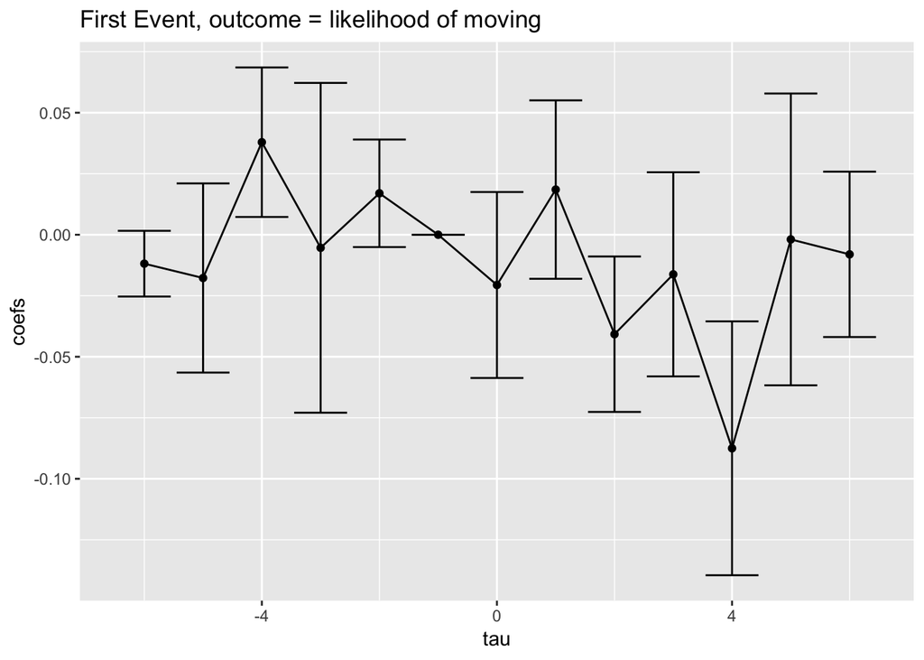

```r
#find indices of taus for first event treating each row
first_event_indices<-grep("Tau_1",names(test_run$coefficients))
data.frame(coefs=test_run$coefficients[first_event_indices],
           tau_string=names(test_run$coefficients)[first_event_indices],
           #specify range as 1.96*sd
           error=test_run$std.error[first_event_indices]*1.96)%>%
  #add in the zero tau
  rbind(data.frame(coefs=0,
                   tau_string=paste0('`',norm_year_tau,'`'),
                   error=0))%>%
  #make tau numeric
  mutate(tau_string=gsub('`','',tau_string),
         tau=as.numeric(gsub('Tau_._','',tau_string)))%>%
  ggplot(aes(x=tau,y=coefs))+
  geom_point(aes(x=tau,y=coefs))+
  geom_line()+
  geom_errorbar(aes(ymin=coefs-error,ymax=coefs+error))+
  labs(title="First Event, outcome = likelihood of moving")
```

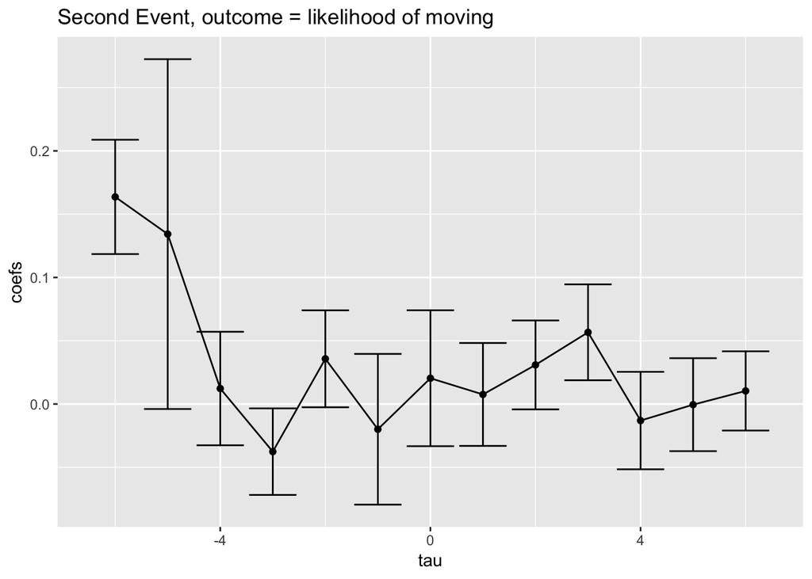

```r
#find indices of taus for first event treating each row
first_event_indices<-grep("Tau_2",names(test_run$coefficients))
data.frame(coefs=test_run$coefficients[first_event_indices],
           tau_string=names(test_run$coefficients)[first_event_indices],
           #specify range as 1.96*sd
           error=test_run$std.error[first_event_indices]*1.96)%>%
  #make tau numeric
  mutate(tau_string=gsub('`','',tau_string),
         tau=as.numeric(gsub('Tau_._','',tau_string)))%>%
  ggplot(aes(x=tau,y=coefs))+
  geom_point(aes(x=tau,y=coefs))+
  geom_line()+
  geom_errorbar(aes(ymin=coefs-error,ymax=coefs+error))+
  labs(title="Second Event, outcome = likelihood of moving")
```

[figure not shown]

```r
#find indices of taus for first event treating each row
first_event_indices<-grep("Tau_3",names(test_run$coefficients))
data.frame(coefs=test_run$coefficients[first_event_indices],
           tau_string=names(test_run$coefficients)[first_event_indices],
           #specify range as 1.96*sd
           error=test_run$std.error[first_event_indices]*1.96)%>%
  #make tau numeric
  mutate(tau_string=gsub('`','',tau_string),
         tau=as.numeric(gsub('Tau_._','',tau_string)))%>%
  ggplot(aes(x=tau,y=coefs))+
  geom_point(aes(x=tau,y=coefs))+
  geom_line()+
  geom_errorbar(aes(ymin=coefs-error,ymax=coefs+error))+
  labs(title="Third Event, outcome = likelihood of moving")
```

```r
#create the formula for the event study

#fetch names of for_event_study_moves that contain the string Tau
taus_list<-names(outcome_disadvantage_change)[grep("Tau",names(outcome_disadvantage_change))]

#normalize around zero_tau of first year


norm_year_tau<-paste0("Tau_1_",zero_tau)
taus_list<-taus_list[taus_list!=norm_year_tau]

#wrap each tau list in ` ` for formula
for(i in 1:length(taus_list)){
  taus_list[i]<-paste0('`',taus_list[i],'`')
}
taus_string<-paste0(taus_list,collapse=" + ")
formula<-as.formula(paste0("disadvantage_change~",taus_string))

test_run<-lm_robust(formula,data=outcome_disadvantage_change,
                    fixed_effects=t+start_hood,clusters=start_hood,se_type="stata")
summary(test_run)
```

```
##
## Call:
## lm_robust(formula = formula, data = outcome_disadvantage_change,
##     clusters = start_hood, fixed_effects = t + start_hood, se_type = "stata")
##
## Standard error type:  stata
##
## Coefficients:
##              Estimate Std. Error  t value Pr(>|t|) CI Lower  CI Upper DF
## `Tau_1_-6` -0.0228508    0.02001 -1.14217   0.2669 -0.06458  0.018882 20
## Tau_1_6    -0.0394959    0.04431 -0.89142   0.3833 -0.13192  0.052926 20
## Tau_2_2     0.0594994    0.03967  1.49982   0.1493 -0.02325  0.142252 20
## Tau_2_6     0.0026579    0.03944  0.06739   0.9469 -0.07961  0.084925 20
## `Tau_2_-2`  0.0133658    0.03289  0.40643   0.6887 -0.05523  0.081965 20
## `Tau_1_-3` -0.0237371    0.00932 -2.54699   0.0192 -0.04318 -0.004297 20
## `Tau_2_-1`  0.0517813    0.04458  1.16158   0.2591 -0.04121  0.144770 20
## Tau_1_0    -0.0648847    0.05612 -1.15615   0.2612 -0.18195  0.052183 20
## Tau_1_4    -0.0578314    0.07729 -0.74827   0.4630 -0.21905  0.103385 20
## `Tau_2_-6`  0.0474473    0.04363  1.08743   0.2898 -0.04357  0.138463 20
## Tau_1_5    -0.0240864    0.03734 -0.64513   0.5262 -0.10197  0.053795 20
## `Tau_2_-5`  0.0205879    0.05654  0.36413   0.7196 -0.09735  0.138529 20
## Tau_2_0    -0.0015962    0.03586 -0.04451   0.9649 -0.07640  0.073213 20
## Tau_2_1     0.0131540    0.03981  0.33044   0.7445 -0.06988  0.096190 20
## `Tau_2_-4`  0.0057179    0.04458  0.12826   0.8992 -0.08728  0.098713 20
## `Tau_2_-3`  0.0118504    0.02978  0.39790   0.6949 -0.05028  0.073976 20
## Tau_1_3    -0.0274718    0.04602 -0.59696   0.5572 -0.12347  0.068523 20
## Tau_2_5     0.0585493    0.05455  1.07337   0.2959 -0.05523  0.172333 20
## Tau_2_4    -0.0191835    0.03482 -0.55088   0.5878 -0.09182  0.053457 20
## Tau_1_2     0.0004467    0.03408  0.01311   0.9897 -0.07064  0.071533 20
## Tau_1_1    -0.0569364    0.03748 -1.51909   0.1444 -0.13512  0.021247 20
## Tau_2_3     0.0393479    0.04184  0.94049   0.3582 -0.04792  0.126620 20
## `Tau_1_-4`  0.0392332    0.04772  0.82215   0.4207 -0.06031  0.138775 20
## `Tau_1_-2`  0.0255570    0.03798  0.67282   0.5088 -0.05368  0.104792 20
## `Tau_1_-5`  0.0172608    0.02854  0.60473   0.5522 -0.04228  0.076800 20
##
## Multiple R-squared:  0.3951 ,    Adjusted R-squared:  0.3857
## Multiple R-squared (proj. model):  0.007394 ,    Adjusted R-squared (proj. model):  -0.008049
## F-statistic (proj. model):    NA on 25 and 20 DF,  p-value: NA
```

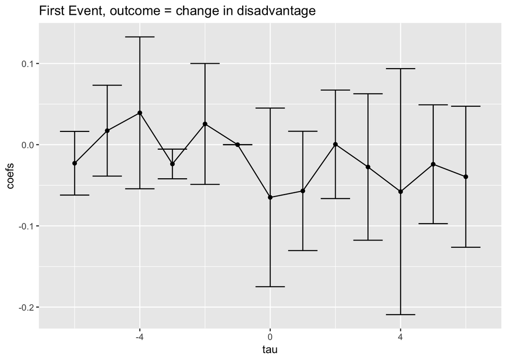

```r
#find indices of taus for first event treating each row
first_event_indices<-grep("Tau_1",names(test_run$coefficients))
data.frame(coefs=test_run$coefficients[first_event_indices],
           tau_string=names(test_run$coefficients)[first_event_indices],
           #specify range as 1.96*sd
           error=test_run$std.error[first_event_indices]*1.96)%>%
  #add in the zero tau
  rbind(data.frame(coefs=0,
                   tau_string=paste0('`',norm_year_tau,'`'),
                   error=0))%>%
  #make tau numeric
  mutate(tau_string=gsub('`','',tau_string),
         tau=as.numeric(gsub('Tau_._','',tau_string)))%>%
  ggplot(aes(x=tau,y=coefs))+
  geom_point(aes(x=tau,y=coefs))+
  geom_line()+
  geom_errorbar(aes(ymin=coefs-error,ymax=coefs+error))+
  labs(title="First Event, outcome = change in disadvantage")
```

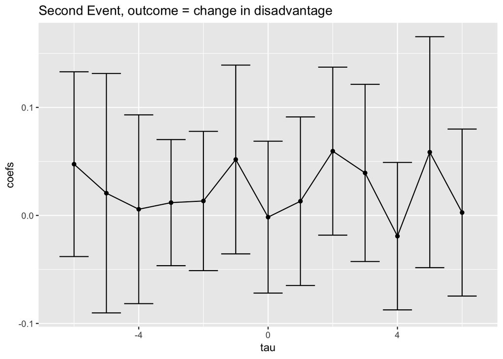

```r
#find indices of taus for first event treating each row
first_event_indices<-grep("Tau_2",names(test_run$coefficients))
data.frame(coefs=test_run$coefficients[first_event_indices],
           tau_string=names(test_run$coefficients)[first_event_indices],
           #specify range as 1.96*sd
           error=test_run$std.error[first_event_indices]*1.96)%>%
  #make tau numeric
  mutate(tau_string=gsub('`','',tau_string),
         tau=as.numeric(gsub('Tau_._','',tau_string)))%>%
  ggplot(aes(x=tau,y=coefs))+
  geom_point(aes(x=tau,y=coefs))+
  geom_line()+
  geom_errorbar(aes(ymin=coefs-error,ymax=coefs+error))+
  labs(title="Second Event, outcome = change in disadvantage")
```

```r
#create a function that just returns x, to test vectorizing
# return_x=function(x){
#   return(x%>%
#            as.data.frame()%>%
#            mutate(some_added_column="test"))
# }
#
# test<-apply(panel_frame%>%
#               as.data.frame()%>%
#               select(-geometry),1,function(y)return_x(x=y))%>%as.data.frame()
```